# Exploratory Data Analysis

Statistical Learning - Week 2

Julie Bessac

2026

## Why Do We Need EDA?

> *Most modeling failures are caused by poor data understanding, not poor algorithms.*

EDA helps us:

- Understand the **data-generating process**
- Detect **structure/dependencies, anomalies, and limitations**
- Decide **what models make sense**
- Avoid costly mistakes (leakage, wrong assumptions)

## Where EDA Fits in the Data Science Pipeline

**Raw data → EDA → Feature engineering → Modeling → Evaluation**

EDA is:

- Iterative
- Non-formal
- Question-driven

> You perform EDA *before* trusting any subsequent model output.

> EDA is entirely driven by YOU.

## What Is Exploratory Data Analysis?

**Definition**  
Exploratory Data Analysis is the use of **visualization, summary statistics, and simple transformations** to understand the main characteristics of a dataset.

Key ideas:

- Let the data speak
- Prefer plots over metrics (early on)
- Look for surprises, not confirmation

Personally, I always start with qualitative aspects and visualization and then work on quantitative aspects.

## EDA vs Statistical Inference

| EDA | Statistical Inference |
| --- | --- |
| Discovery | Confirmation |
| Flexible | Formal |
| Visual | Mathematical |
| No p-values | p-values |

EDA often **guides** what inference is appropriate later.

## First Look: Always Start Simple

**Questions to ask immediately:**

- How big is the dataset? Does it fit R and-or my computer?
- What is the format?
- What are the variables and units?
- What is the time resolution?
- Are there missing values?

**Typical first plots:**

- Single scatterplot / Time series plot
- Histograms, boxplots
- Summary table

**First:** look at individual variables

**Second:** explore the multivariate aspects

**Third:** hidden and more complex structures  
e.g. dependence to categories (e.g. regime), time-changing properties/non-stationarity, …

## Univariate EDA: One Variable at a Time

Goal: understand **distribution and scale**

Tools:

> - Single scatterplot / Time series plot
> - Histogram / density plot
> - Boxplot
> - Mean, median, variance, IQR

Questions:

> - Is the distribution symmetric? Skewed?
> - Is the distribution *multi-modal*?
> - Are there outliers? Heavy tails?
> - Is a transformation needed?

## Exemple Dataset

**Electricity Load + Weather (Hourly)**

Variables include:

- Electricity demand (MW)
- Weather variables (temperature, wind speed, rainfall, …)
- Calendar features (hour, weekday, day of the week, season)

Properties:

- Multivariate
- Time-dependent
- Nonlinear relationships

## Example: Electricity Load (Demand)

What are your thoughts here?

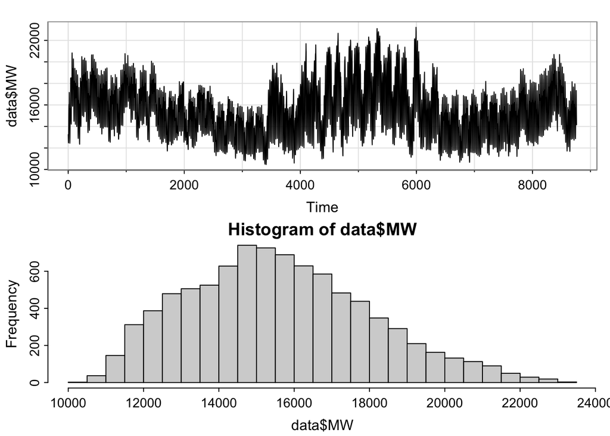

Implication:

A simple linear-Gaussian model may be inappropriate.

## Bivariate EDA: Relationships Between Variables

Goal: understand **dependence** betwen variables

Tools:

- Scatter plots
- Conditional boxplots
- Correlation (Pearson vs Spearman)

Important warning:

Correlation can miss nonlinear relationships.

## Example: Load vs Weather Variables

How would you model such relationships?

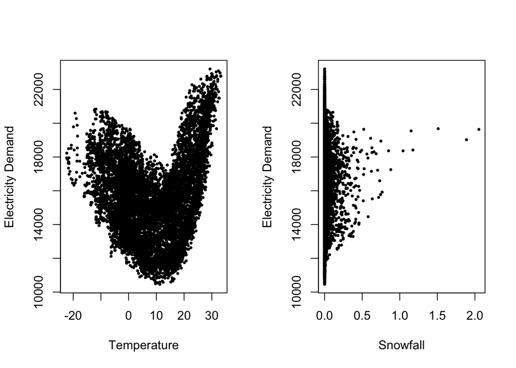

## Example: Load vs Temperature

Clear pattern:

- U-shaped relationship
- Heating and cooling regimes

Key lesson:

- Low correlation ≠ no relationship
- Visualization reveals structure missed by metrics

Demand and snowfall’s relationship even more complex,  
It pertains to the class of regime dependence (wet/dry regimes).

## Hidden Structure Through Conditioning

Some relationships cannot always be highlighted by scatterplots,  
due ot their complexity and-or the nature of data.

- Hour of day
- Day of the week
- Season

Technique:

- Color or facet plots by group

EDA reveals **latent variables**.

What would you like to see from the electricity demand?

How would you model such relationships?

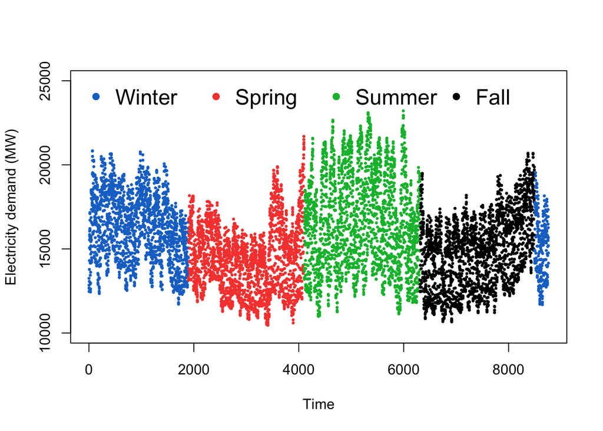

How would you model such relationships?

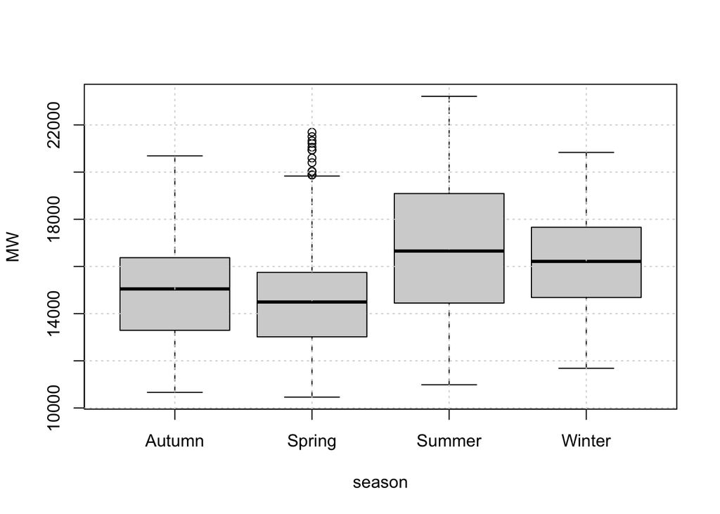

## Hidden Structure Through Conditioning

These types of structures are typically hard to model,

Adding extra covariates does not solve the issue,

Because there are non-linearities in the systems,

Often we need models that enable conditioning,

So that, parts of the model differ depending on a factor or a latent variable.

Examples are mixture models, state-space models, hierarchical models.

## Multivariate EDA

Goal: explore structure across many variables

Tools:

- Pair plots
- Correlation heatmaps
- Grouped summaries
- PCA (for exploration, not prediction)

Ask:

- Redundant variables?
- Strong dependencies?
- Clusters or regimes?

## Multivariate EDA

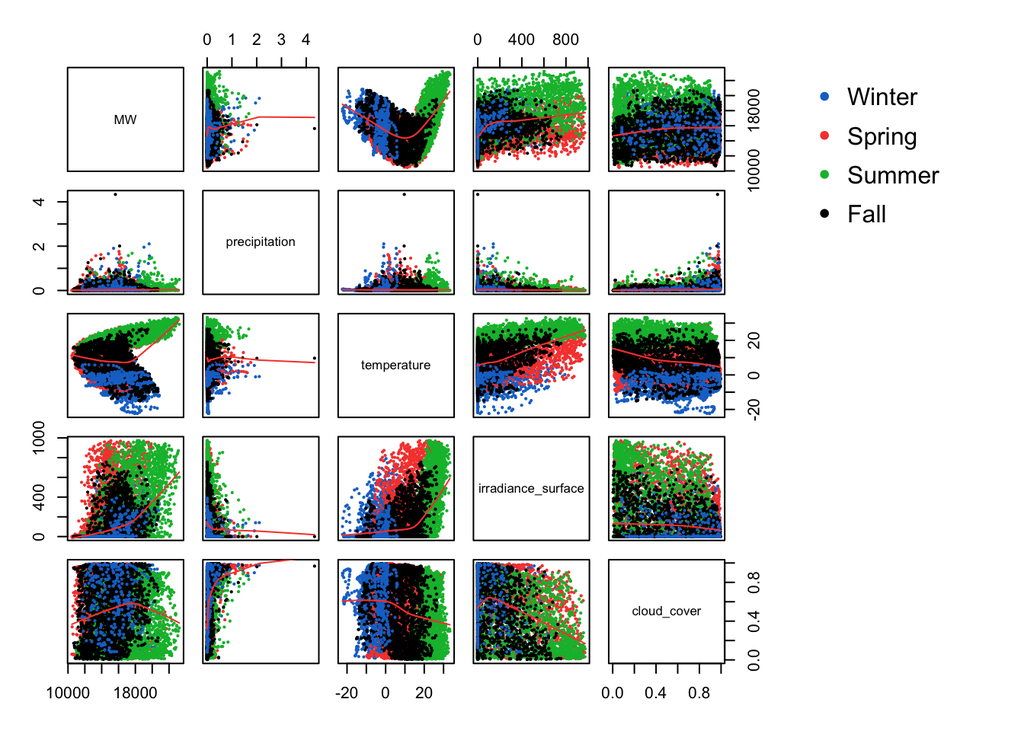

## Time Series–Specific EDA

Key questions:

- Is the process stationary?
- Are there trends or seasonality?
- Are there regime changes?

Tools:

- Time plots
- Seasonal decomposition
- Autocorrelation plots

## Data Quality Checks (Critical!)

Things to look for:

- Missing data
- Outliers
- Duplicates
- Inconsistent units
- Data leakage (we will talk about that in future classes)

Rule of thumb:

> Never clean data before understanding *why* it is dirty.

## Missing Data: An EDA Perspective

Questions:

- How much data is missing?
- Is it random or structured?
- Does missingness depend on time or values?

Visualization:

- Missingness heatmaps
- Time-ordered missing indicators

Treatment: case by case

## EDA as Hypothesis Generation

EDA helps us form modeling hypotheses:

| EDA Observation | Modeling Consequence |
| --- | --- |
| Seasonality | Periodic terms as predictors |
| Nonlinearity | GAMs, trees |
| Regimes | Mixture models |
| Heteroscedasticity | Transformation, Weighted models |

## From EDA to Modeling Choices

Example pipeline:

1. EDA shows strong daily seasonality
2. Hypothesis: periodic structure
3. Feature engineering: hour-of-day
4. Model: regression with seasonal terms

EDA **reduces the model search space**.

## Common EDA Pitfalls

- Over-interpreting noise
- Cleaning too early
- Ignoring data provenance
- Relying only on summary statistics
- Skipping visual checks

**Remember:** A model cannot fix misunderstood data.

## Key Takeaways

- EDA is not optional
- Visualization is your strongest tool
- Always question assumptions
- Good EDA saves time and prevents failure

*Better data understanding beats better algorithms.*

**EDA is the first step toward trustworthy statistical learning.**